# Machine Learning

## Indah Agustien Siradjuddin

## Principal Component Analysis

Semester Gasal 2019-2020

### Reduksi Dimensi

Pentingnya Reduksi Dimensi :

1. Curse of Dimensionality, semakin besar dimensi data, maka semakin besar pula sample yang dibutuhkan untuk data pelatihan
2. Kompressi data dan tetap meminimalkan informasi yang hilang
3. Memudahkan visualisasi dan analisa data daripada data dengan dimensi yang cukup besar

PCA mereduksi dimensi dengan cara memproyeksikan data ke dalam ruang dengan dimensi yang lebih rendah.

- Data dengan dua dimensi dapat diproyeksikan ke dalam sebuah garis
- Data tiga dimensi diproyeksikan ke dalam ruang dua dimensi
- Data dengan *n* dimensi dapat diproyeksikan ke dalam *k* ruang dimensi, dimana $k<n$

PCA tidak hanya mereduksi dimensi dengan memproyeksikan data, akan tetapi error hasil proyeksi reduksi tetap dapat diminimalkan, dan mempertahankan variance dari sample data:

[figure not shown]

Sumber :

### Proyeksi Data

Proyeksi data dilakukan untuk memproyeksikan data dari suatu ruang dimensi, ke dalam ruang dimensi yang lain. Hasil proyeksi data ini tidak akan merubah data, hanya merubah representasi data.

[figure not shown]

Sumber :

Proyeksi Data :

[figure not shown]

Sumber :

### Principal Component Analysis (PCA)

Konsep dasar untuk PCA

**Variance** : merepresentasikan sebaran suatu data.

\begin{eqnarray} var(X)=\frac{\sum_{i=1}^{n}(X_i-\bar{X})(X_i-\bar{X})}{n-1} \end{eqnarray}

dimana $X$ adalah data, dan $n$ adalah jumlah data

**Covariance** : adalah variance antara satu fitur dengan fitur yang laing, biasanya digunakan untuk menganalisa korelasi antara fitur.

\begin{eqnarray} cov(x,y)=\frac{\sum_{i=1}^{n}(x_i-\bar{x})(y_i-\bar{y})}{n-1} \end{eqnarray}

dimana $x$ dan $y$ adalah fitur pada dimensi $x$ dan $y$

Matriks covariance yang dibentuk dari dua buah fitur $(x,y)$ adalah : \begin{eqnarray} cov= \begin{bmatrix} cov(x,x) & cov(x,y) \\ cov(y,x) & cov(y,y) \end{bmatrix} \end{eqnarray} Matriks covariance yang diperoleh adalah matriks simetris dengan diagonal berupa variance dari masing-masing fitur, dan $cov(x,y)=cov(y,x)$

Matriks covariance yang dibentuk dari tiga buah fitur $(x,y,z)$ adalah : \begin{eqnarray} cov= \begin{bmatrix} cov(x,x) & cov(x,y) & cov(x,z) \\ cov(y,x) & cov(y,y) & cov(y,z) \\ cov(z,x) & cov(z,y) & cov(z,z) \end{bmatrix} \end{eqnarray}

```python
import numpy as np
from sklearn import datasets
```

Berikut adalah contoh perhitungan covariance untuk data iris (5 data sample, dan 2 fitur), maka matriks covariance yang dibentuk berukuran 2 x 2

```python
iris=datasets.load_iris()
featIris=iris.data[:5,:2]
targetIris=iris.target
```

```python
featIris
```

```
array([[ 5.1,  3.5],
       [ 4.9,  3. ],
       [ 4.7,  3.2],
       [ 4.6,  3.1],
       [ 5. ,  3.6]])
```

Matriks covariance dari data tersebut adalah sebagai berikut :

[figure not shown]

Fungsi covariance juga disediakan oleh numpy, perhatikan argumen untuk fungsi covariance. Dokumentasi untuk covariance dengan menggunakan numpy dapat dilihat di : https://docs.scipy.org/doc/numpy/reference/generated/numpy.cov.html?highlight=cov#numpy.cov

```python
np.cov(featIris.T)
```

```
array([[ 0.043 ,  0.0365],
       [ 0.0365,  0.067 ]])
```

```python
np.cov(featIris,rowvar=False)
```

```
array([[ 0.043 ,  0.0365],
       [ 0.0365,  0.067 ]])
```

### Ekstraksi Fitur

**Principal Component Analysis (PCA)** adalah metode ekstraksi fitur, yang mampu :

- mereduksi jumlah fitur
- menyimpan informasi-informasi penting suatu data- memilih *principal components* yang memiliki nilai variance besar

Proses ekstraksi fitur dilakukan dengan cara **memproyeksikan** data-data fitur dengan dimensi $n$ ke dalam ruang dimensi $k$ dimana $k<n$.  
**Eigenvector** : Matriks Proyeksi  
**Eigenvector** merupakan suatu matriks yang berisi principal components yang terpilih berdasarkan nilai **eigenvalue**. Dengan eigenvector ini diharapkan dapat memproyeksikan data fitur ke dalam ruang dimensi baru, dengan nilai variance yang besar.

#### Eigenvalue dan Eigenvector

\begin{eqnarray} Av=\lambda v \end{eqnarray}

dimana :  
$A$ : **matriks bujur** sangkar berukuran $nxn$  
$v$ : eigenvector yang berkesesuaian  
$\lambda$ : eigenvalue berupa nilai skalar.

Persamaan eigenvector tersebut dapat diselesaikan dengan cara : \begin{eqnarray} Av&=&\lambda v\\ Av-\lambda v&=& 0\\ Av-\lambda I v&=& 0\\ (A-\lambda I) v&=& 0\\ \end{eqnarray} dengan \begin{eqnarray} |A-\lambda I|= 0\\ \end{eqnarray}

Misalkan terdapat matriks $A$ sebagai berikut :

\begin{eqnarray} A= \begin{bmatrix} 1 & 1 \\ -5 & 7 \end{bmatrix} \end{eqnarray}

Maka eigenvector dan eigenvalue dapat dihitung sebagai berikut :

Dokumentasi untuk eigenvector dan eigenvalue di dalam numpy dapat dilihat : https://docs.scipy.org/doc/numpy/reference/generated/numpy.linalg.eig.html?highlight=eig#numpy.linalg.eig

```python
A=np.array([[1,1],[-5,7]])
A
```

```
array([[ 1,  1],
       [-5,  7]])
```

```python
eigVal,eigVec=np.linalg.eig(A)
print(eigVal)
print(eigVec)
```

```
[ 2.  6.]
[[-0.70710678 -0.19611614]
 [-0.70710678 -0.98058068]]
```

#### Ekstraksi fitur dengan menggunakan Eigenvalue dan Eigenvector

1. Hitung zeromean dari dataset
2. Hitung covariance matrix dari matrix zeromean
3. Hitung Eigenvalue dan eigenvector
4. Pemilihan principal components berdasarkan eigenvalue
5. Proyeksi dataset

Misalkan terdapat data random dengan jumlah data=20 dan jumlah fitur =2

```python
data=np.random.rand(20,2)
data
```

```
array([[ 0.31175273,  0.83635026],
       [ 0.33799249,  0.46726555],
       [ 0.49044417,  0.76300497],
       [ 0.09653474,  0.26987152],
       [ 0.88523225,  0.83755689],
       [ 0.05458413,  0.02813004],
       [ 0.61727268,  0.02885714],
       [ 0.60235539,  0.6806171 ],
       [ 0.88992798,  0.51101783],
       [ 0.24511898,  0.26268433],
       [ 0.89418907,  0.17703585],
       [ 0.75620744,  0.97849678],
       [ 0.42755195,  0.39929863],
       [ 0.56929907,  0.4274317 ],
       [ 0.2031477 ,  0.78096827],
       [ 0.59603799,  0.55874537],
       [ 0.98435417,  0.91154963],
       [ 0.97419924,  0.68256081],
       [ 0.71064237,  0.94831504],
       [ 0.34264248,  0.57670844]])
```

```python
import matplotlib.pyplot as matPlot
```

```python
%matplotlib inline
```

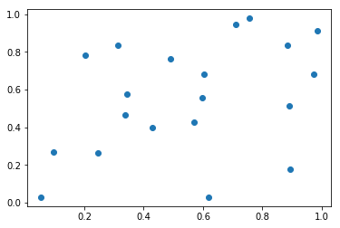

```python
matPlot.plot(data[:,0],data[:,1],'o')
```

#### Zeromean

```python
xBar=np.mean(data[:,0])
yBar=np.mean(data[:,1])
print(xBar,yBar)
```

```
0.549474351139 0.556323307429
```

```python
barData=np.array([xBar,yBar])
zeroMeanData=data-barData
print(zeroMeanData)
```

```
[[-0.23772162  0.28002695]
 [-0.21148186 -0.08905776]
 [-0.05903018  0.20668166]
 [-0.45293962 -0.28645179]
 [ 0.3357579   0.28123358]
 [-0.49489022 -0.52819326]
 [ 0.06779833 -0.52746617]
 [ 0.05288104  0.12429379]
 [ 0.34045363 -0.04530548]
 [-0.30435538 -0.29363898]
 [ 0.34471472 -0.37928746]
 [ 0.20673309  0.42217348]
 [-0.1219224  -0.15702468]
 [ 0.01982472 -0.1288916 ]
 [-0.34632665  0.22464497]
 [ 0.04656364  0.00242206]
 [ 0.43487982  0.35522632]
 [ 0.42472489  0.1262375 ]
 [ 0.16116802  0.39199173]
 [-0.20683187  0.02038513]]
```

#### Covariance

```python
covData=np.cov(zeroMeanData.T)
print(covData)
```

```
[[ 0.0852979   0.03330961]
 [ 0.03330961  0.08742999]]
```

#### EigenValue dan EigenVector

```python
eigVal,eigVec=np.linalg.eig(covData)
print(eigVal)
print(eigVec)
```

```
[ 0.05303728  0.11969061]
[[-0.71832717 -0.69570546]
 [ 0.69570546 -0.71832717]]
```

Garis Proyeksi yang dihasilkan adalah :

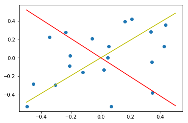

```python
testData=np.linspace(-0.5,0.5,100)
y1=-(0.718/0.69)*testData
y2=(0.695/0.718)*testData
matPlot.plot(zeroMeanData[:,0],zeroMeanData[:,1],'o')
matPlot.plot(testData,y1,'r-')
matPlot.plot(testData,y2,'y-')
```

#### Pemilihan Principal Components

Principal components dipilih sehingga data hasil proyeksi tetap memberikan nilai variance yang cukup besar.

Sehingga matriks proyeksi yang dihasilkan adalah : $[-0.695, -0.718]$

#### Proyeksi Dataset

Proyeksi dataset dapat dilakukan dengan cara : <br> $hasilProyeksi=eigenvector^T\times zeromeanData^T$

```python
eigMatrix=eigVec[:,1].T
print(eigMatrix)
extFeature=eigMatrix.dot(zeroMeanData.T)
newFeat=extFeature.T
print(newFeat)
```

```
[-0.69570546 -0.71832717]
[-0.03576674  0.21110169 -0.10739743  0.52087866 -0.43560632  0.7237134
  0.33172561 -0.12607323 -0.20431129  0.42267055  0.03263258 -0.44708401
  0.19761717  0.07879418  0.07957276 -0.03413441 -0.55771698 -0.38616325
 -0.39370378  0.12925087]
```

```python
newFeature=zeroMeanData.dot(eigMatrix)
print(newFeature)
print(newFeature.shape)
```

```
[-0.03576674  0.21110169 -0.10739743  0.52087866 -0.43560632  0.7237134
  0.33172561 -0.12607323 -0.20431129  0.42267055  0.03263258 -0.44708401
  0.19761717  0.07879418  0.07957276 -0.03413441 -0.55771698 -0.38616325
 -0.39370378  0.12925087]
(20,)
```

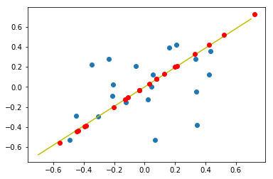

```python
testData=np.linspace(-0.7,0.7,100)
y2=(-0.69570546/-0.71832717)*testData
matPlot.plot(zeroMeanData[:,0],zeroMeanData[:,1],'o')
matPlot.plot(testData,y2,'y-')
matPlot.plot(newFeature,newFeature,'ro')
```

### PCA untuk Ekstraksi Fitur

#### Covariance dari data fitur

Misalkan terdapat $N$ buah data dengan sejumlah $d$ fitur, maka covariance matriks data tersebut (matriks zeromean) adalah:

\begin{eqnarray} C=\frac{1}{N-1}\bar{X}^T\bar{X} \end{eqnarray}

dimana $\bar{X}$ adalah matriks zeromean berukuran $N \times d$, sehingga matriks $C$ berukuran $d \times d$

#### Eigenvalue dan Eigenvector

Nilai eigenvalue dan eigenvector dihitung berdasarkan matriks covariance : \begin{eqnarray} Cv=\lambda v \end{eqnarray} Dimana $v$ adalah eigenvector yang berbentuk bujursangkar dengan ukuran $d \times d$

\begin{eqnarray} Cv&=&\lambda v\\ \bar{X}^T\bar{X}v&=&\lambda v\\ \bar{X}\bar{X}^Tv'&=&\lambda' v' \end{eqnarray}

Secara umum ukuran dimensi jauh lebih besar dibandingkan jumlah data, oleh karena itu diperlukan transformasi, agar didapatkan matriks covariance yang lebih kecil.

\begin{eqnarray} \bar{X}\bar{X}^Tv'&=&\lambda' v'\\ \bar{X}^T\bar{X}\bar{X}^Tv'&=&\lambda' \bar{X}^Tv'\\ \bar{X}^T\bar{X}v&=&\lambda v \end{eqnarray}

dimana $v=\bar{X}^Tv'$ dan $\lambda=\lambda'$

ukuran eigenvector atau $v$ dalam persamaan tersebut, sudah otomatis tereduksi, bukan lagi matriks bujur sangkar, tetapi sudah tereduksi menjadi $d \times N$, yaitu jumlah fitur sudah berkurang menjadi $N$.

Jika akan dilakukan reduksi lagi, sehingga ukuran eigenvector menjadi $d \times M$, dimana $M < N$

### Klasifikasi Handwritten Digits dengan menggunakan PCA dan CART

```
[0 1 2 3 4 5 6 7 8 9]
[[  0.   0.   5.  13.   9.   1.   0.   0.]
 [  0.   0.  13.  15.  10.  15.   5.   0.]
 [  0.   3.  15.   2.   0.  11.   8.   0.]
 [  0.   4.  12.   0.   0.   8.   8.   0.]
 [  0.   5.   8.   0.   0.   9.   8.   0.]
 [  0.   4.  11.   0.   1.  12.   7.   0.]
 [  0.   2.  14.   5.  10.  12.   0.   0.]
 [  0.   0.   6.  13.  10.   0.   0.   0.]]
```

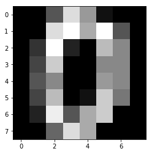

```python
dataHandWritten=datasets.load_digits()
print(dataHandWritten.target_names)
data1=dataHandWritten.images[0]
data2=dataHandWritten.images[100]
print(data1)
matPlot.imshow(data1,cmap='gray')
```

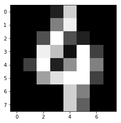

```python
matPlot.imshow(data2,cmap='gray')
```

```python
from sklearn.model_selection import KFold
from sklearn. tree import DecisionTreeClassifier
from sklearn.cross_validation import train_test_split
from sklearn.cross_validation import cross_val_score
from sklearn.metrics import classification_report
```

```python
featureData=dataHandWritten.data
print(featureData.shape)
targetData=dataHandWritten.target
Xtrain, Xtest, ytrain, ytest = train_test_split(featureData, targetData)
print(Xtrain.shape)
print(len(Xtrain))
```

```
(1797, 64)
(1347, 64)
1347
```

```python
treeClf=DecisionTreeClassifier()
treeClf.fit(Xtrain, ytrain)
predictions = treeClf.predict(Xtest)
print (classification_report(ytest, predictions))
```

```
             precision    recall  f1-score   support

          0       0.93      0.93      0.93        43
          1       0.80      0.90      0.85        40
          2       0.84      0.84      0.84        49
          3       0.79      0.78      0.78        40
          4       0.81      0.79      0.80        43
          5       0.75      0.92      0.83        36
          6       0.96      0.91      0.93        47
          7       0.92      0.77      0.84        62
          8       0.72      0.72      0.72        43
          9       0.79      0.81      0.80        47

avg / total       0.84      0.83      0.83       450
```

#### PCA

```python
from sklearn.decomposition import PCA
```

```python
pca = PCA(n_components=20)
XtrainPCA = pca.fit_transform(Xtrain)
XtestPCA = pca.transform(Xtest)
print(XtrainPCA.shape)
```

```
(1347, 20)
```

```python
treeClfPCA=DecisionTreeClassifier()
treeClfPCA.fit(XtrainPCA, ytrain)
predictionsPCA = treeClfPCA.predict(XtestPCA)
print (classification_report(ytest, predictionsPCA))
```

```
             precision    recall  f1-score   support

          0       0.93      0.91      0.92        43
          1       0.82      0.80      0.81        40
          2       0.85      0.80      0.82        49
          3       0.81      0.75      0.78        40
          4       0.91      0.91      0.91        43
          5       0.89      0.94      0.92        36
          6       0.95      0.87      0.91        47
          7       0.86      0.82      0.84        62
          8       0.67      0.81      0.74        43
          9       0.76      0.83      0.80        47

avg / total       0.85      0.84      0.84       450
```